# Project Assessment 1 - Reproducible Research

Alberto Camilli

Saturday, March 14, 2015

### Loading and preprocessing the data.

First I´m going to read the data then I´ll eliminate the rows with NAs and generate a df with no NA (dfNOna)

```r
setwd("F:/Coursera Reproducible Research")
df<-read.csv("./activity.csv")
#eliminate NA rows
dfNOna<-df[complete.cases(df),]
```

Now I´m going calculate average values over the remaining data.First I need to kwow the #days and the #steps per day. Results will be stored in a table (tabela1) so it can be retrieved whenever wanted. The total #steps per day will be plotted. Mean and median are subsequently calculated.

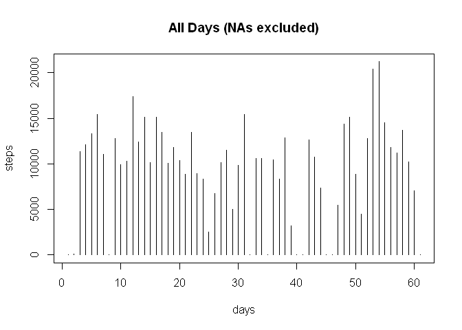

```r
days<-levels(dfNOna$date)
tabela1<-c()
for (day in days){
  ss<-subset(dfNOna, date==day, select=steps)
  values<-c(day, sum(ss$steps))
  tabela1<-rbind(values, tabela1)
}
tabela1<-apply(tabela1,2,rev)
plot(tabela1[,2],main="All Days (NAs excluded)", xlab="days",ylab="steps", type="h") #(Q2. histogram)
```

```r
# (Q3. mean and median # steps per day, with NA excluded)
```

### What is mean total number of steps taken per day?

Mean and median for the expurged data frame:

```r
mean(as.numeric(tabela1[,2]))
```

```
## [1] 9354.23
```

```r
median(as.numeric(tabela1[,2]))
```

```
## [1] 10395
```

### What is the average daily activity pattern?

Now I want to know the averages over each 5 minute interval. I´ll build up a second table, tabela2 and then plot the #steps per 5 minute interval

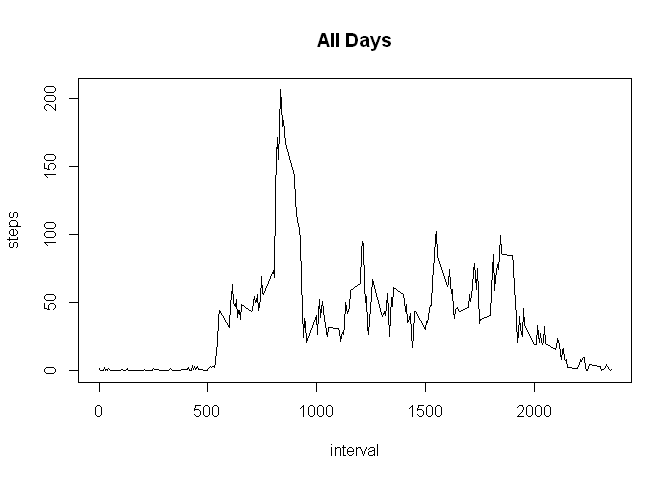

```r
#determine average number of steps in the 5 minute intervals across all days
intf<-factor(dfNOna$interval)
intervals<-levels(intf)
tabela2<-c()
for (intervalo in intervals) {
  ss<-subset(dfNOna, interval==intervalo, select=steps)
  values<-c(intervalo, mean(ss$steps))
  tabela2<-rbind(values, tabela2)
}
tabela2<-apply(tabela2,2,rev)
# (Q1. plot acroos all days)
plot(tabela2[,1], main="All Days", xlab="interval",ylab="steps",tabela2[,2], type="l")
```

It can be seen that the maximum number of steps per interval is:

```r
# maximum number of steps
max(as.numeric(tabela2[,2]))
```

```
## [1] 206.1698
```

which occours at the interval:

```r
# (Q2. 5-minute interval with maximum number of steps)
which.max(tabela2[,2])
```

```
## values
##    104
```

### Imputing missing values

Now I´m going to replace the excluded NAs with values that will be estimated as the average #steps for the existing data. First I´ll calculate the number of NA rows in the original data frame:

```r
#determine the number of NA rows in original data frame (Q1.)
NArows<-nrow(df)-nrow(dfNOna)
NArows
```

```
## [1] 2304
```

```r
#calculate a criteria for the replace of the NA values (Q2.)
```

Then I´ll calculate the average over valid values in media_geral and use it as a criteria for fill in NA values.So a new data.frame (dfFull) will be constructed from the original one (df) and the same steps taken before will be repeated.

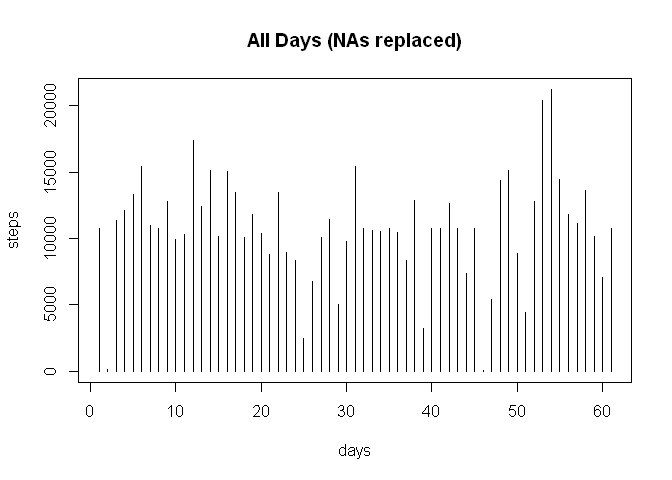

```r
# criteria: media_geral is an average through valid step values and corresponding days
media_geral<- sum(as.numeric(tabela1[,2]))/(61*288-NArows)
#assemble a new and complete data frame (dfFull) with the averaged values (Q3.)
dfFull<-df
tabela3<-c()
for (day in days){
  dfFull$steps[is.na(dfFull$steps)&dfFull$date==day]<-media_geral
  ss<-subset(dfFull, date==day, select=steps)
  values<-c(day, sum(ss$steps), mean(ss$steps))
  tabela3<-rbind(values, tabela3)
}
tabela3<-apply(tabela3,2,rev)
plot(tabela3[,2],main="All Days (NAs replaced)", xlab="days",ylab="steps", type="h")
```

```r
# (3. mean and median # steps, with NA replaced)
```

Mean and median for the stuffed data frame:

```r
mean(as.numeric(tabela3[,2]))
```

```
## [1] 10766.19
```

```r
median(as.numeric(tabela3[,2]))
```

```
## [1] 10766.19
```

### Are there differences in activity patterns between weekdays and weekends?

Now I´m going to compare weekdays to weekend behaviours. A factor variable (period, with 2 levels, weekday and weekend) will be added to the full data frame

```r
#ading a factor variable period for weekends and weekdays
semana<-c("segunda-feira","terça-feira","quarta-feira","quinta-feira","sexta-feira")
#categorizing the days by the week period
dfFull$period<-"weekend"
for (day in days){
  #dfTest$period[weekdays(as.Date(dfTest$date[dfTest$date==day])) %in% semana]<-"weekday"
  dia<-subset(dfFull, date==day, select=date)
  if (weekdays(as.Date(dia$date)) %in% semana) {
    dfFull$period[dfFull$date == day]<-"weekday"
  }
}

tabela4<-c()
tabela5<-c()
for (intervalo in intervals) {
  ss1<-subset(dfFull, interval==intervalo & period=="weekday", select=steps)
  values<-c(intervalo, mean(ss1$steps), "weekday")
  tabela4<-rbind(values, tabela4)
  ss2<-subset(dfFull, interval==intervalo & period=="weekend", select=steps)
  values<-c(intervalo, mean(ss2$steps), "weekend")
  tabela5<-rbind(values, tabela5)
}

tabela4<-apply(tabela4,2,rev)
tabela5<-apply(tabela5,2,rev)
```

Now I join vertically the two tables into a new data.frame (dfm), rename columns, delete row names and plot a panel

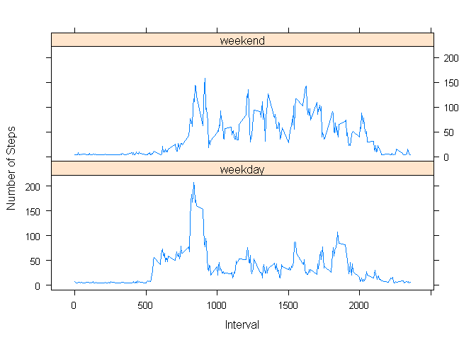

```r
dfm<-rbind(as.data.frame.matrix(tabela4), as.data.frame.matrix(tabela5))
colnames(dfm)<-c("interval", "steps", "period")
rownames(dfm)<-NULL
# loading lattice libray for panel plotting
library(datasets)
library(lattice)
# converting fators to numeric
x<-as.numeric(levels(dfm$steps))[dfm$steps]
y<-as.numeric(levels(dfm$interval))[dfm$interval]
xyplot(x~y|period, data = dfm, type="l",xlab="Interval", ylab="Number of Steps", layout=c(1,2))
```